# EV Infrastructure Modeling

Part 2: Modeling

import datasets from cleaning file

```r
ev_combined_pop <- read.csv("data/ev_combined_pop.csv")
ev_stats <- read.csv("data/ev_stats.csv")
```

predictive linear modeling based on registrations and population goal: predict the number of stations that each state should have based on registration count and population

```r
model_lm = lm(total_stations ~ registration_count + population, data = ev_combined_pop)
summary(model_lm)
```

```
Call:
lm(formula = total_stations ~ registration_count + population,
    data = ev_combined_pop)

Residuals:
    Min      1Q  Median      3Q     Max
-1031.5  -204.5  -102.7   123.2  2277.3

Coefficients:
                    Estimate Std. Error t value Pr(>|t|)
(Intercept)        1.881e+02  1.134e+02   1.659 0.103750
registration_count 1.184e-02  7.525e-04  15.734  < 2e-16 ***
population         6.699e-05  1.821e-05   3.679 0.000602 ***
---
Signif. codes:  0 ‘***’ 0.001 ‘**’ 0.01 ‘*’ 0.05 ‘.’ 0.1 ‘ ’ 1

Residual standard error: 547.3 on 47 degrees of freedom
Multiple R-squared:  0.9578,    Adjusted R-squared:  0.956
F-statistic: 533.6 on 2 and 47 DF,  p-value: < 2.2e-16
```

predict stations based on model expected stations = stations the model predicts should exist in each state based solely on registrations and population station gap = difference between expected stations and current stations

```r
ev_combined_pop <- ev_combined_pop |>
  mutate(expected_stations = round(predict(model_lm), 0),
         station_gap = expected_stations - total_stations) |>
  arrange(desc(station_gap))

ev_combined_pop
```

| X | state | total_stations | registration_count | population | evs_per_station | people_per_station | pop_with_ev | expected_stations | station_gap |
| --- | --- | --- | --- | --- | --- | --- | --- | --- | --- |
| 18 | TX | 3834 | 230125 | 29149458 | 60.02 | 7602.88 | 0.0079 | 4866 | 1032 |
| 11 | FL | 3801 | 254878 | 21538192 | 67.06 | 5666.45 | 0.0118 | 4649 | 848 |
| 7 | NJ | 1586 | 134753 | 9289014 | 84.96 | 5856.88 | 0.0145 | 2406 | 820 |
| 19 | IL | 1546 | 99573 | 12821814 | 64.41 | 8293.54 | 0.0078 | 2226 | 680 |
| 5 | NV | 610 | 47361 | 3105595 | 77.64 | 5091.14 | 0.0153 | 957 | 347 |
| 24 | OK | 380 | 22843 | 3959405 | 60.11 | 10419.49 | 0.0058 | 724 | 344 |
| 47 | LA | 282 | 8150 | 4657874 | 28.90 | 16517.28 | 0.0017 | 597 | 315 |
| 37 | IN | 659 | 26101 | 6786587 | 39.61 | 10298.31 | 0.0038 | 952 | 293 |
| 8 | AZ | 1454 | 89798 | 7158110 | 61.76 | 4923.05 | 0.0125 | 1731 | 277 |
| 42 | KY | 354 | 11617 | 4506302 | 32.82 | 12729.67 | 0.0026 | 628 | 274 |

[output cut: 40 more lines]

visualize station gap from linear model

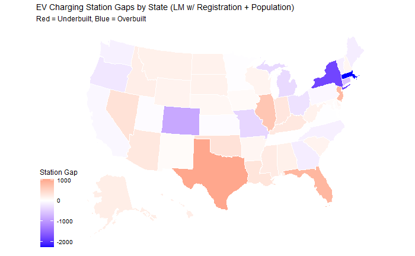

```r
plot_usmap(data = ev_combined_pop, values = "station_gap", color = "white") +
  scale_fill_gradient2(
    low = "blue", mid = "white", high = "red",
    midpoint = 0, name = "Station Gap"
  ) +
  labs(
    title = "EV Charging Station Gaps by State (LM w/ Registration + Population)",
    subtitle = "Red = Underbuilt, Blue = Overbuilt"
  )

ggsave("outputs/ev_charging_station_gaps_by_state_1.png", bg = "skyblue")
```

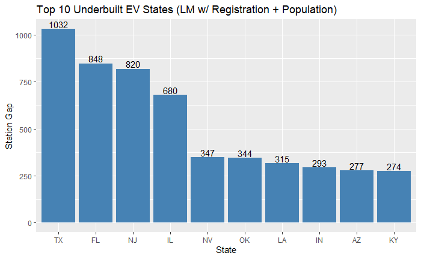

```r
ev_combined_pop_10 <- ev_combined_pop |>
  head(10)

ggplot(ev_combined_pop_10, aes(x = reorder(state, -station_gap), y = station_gap)) +
  geom_bar(stat = "identity", fill = "steelblue") +
  labs(
    title = "Top 10 Underbuilt EV States (LM w/ Registration + Population)",
    x = "State",
    y = "Station Gap"
  ) +
  geom_text(aes(label = station_gap), vjust = -0.2)

ggsave("outputs/top_10_underbuilt_states_1.png")
```

now, let’s get crazy

I believe it is a fair assumption to say that the average person does not worry about where to fuel up when driving an internal combustion engine (ICE) vehicle. Unless driving in extremely rural areas, gas stations are readily available, have enough bays, and experience minimal downtime. Let’s do a better job predicting how many EVs each state will need based on the current gasoline infrastructure.

Gas Station Data: https://afdc.energy.gov/files/u/data/data_source/10333/10333_gasoline_stations_year.xlsx

downside: data only through 2012 (historical trends show a decline in number of gas stations since 1996)

import and clean up data

```r
gas_stations <- read.csv("data/2012_gas_stations_us.csv")

gas_stations <- gas_stations |>
  rename(gas_stations = X2012) |>
  rename(state = State)

gas_stations$state <- state.abb[match(gas_stations$state, state.name)]


gas_stations
```

| state | gas_stations |
| --- | --- |
| AL | 6300 |
| AK | 361 |
| AZ | 2027 |
| AR | 2107 |
| CA | 10100 |
| CO | 2188 |
| CT | 1488 |
| DE | 419 |
| FL | 9037 |
| GA | 8471 |

[output cut: 41 more lines]

join with ev_stats data for analysis

```r
ev_gas_stations <- ev_stats |>
  left_join(gas_stations) |>
  select(state, total_stations, gas_stations) |>
  mutate(difference = gas_stations - total_stations) |>
  arrange(desc(difference))

ev_gas_stations
```

| state | total_stations | gas_stations | difference |
| --- | --- | --- | --- |
| TX | 3834 | 13715 | 9881 |
| GA | 2173 | 8471 | 6298 |
| AL | 506 | 6300 | 5794 |
| FL | 3801 | 9037 | 5236 |
| NC | 1863 | 6270 | 4407 |
| LA | 282 | 3696 | 3414 |
| TN | 1050 | 4400 | 3350 |
| WI | 749 | 3682 | 2933 |
| MI | 1822 | 4749 | 2927 |
| OK | 380 | 3200 | 2820 |

[output cut: 40 more lines]

according to this data, there are only three states with more EV stations than gas stations (CO, MA, CA) all other states have more gas stations than EV stations

let’s do some math with the gas station data and factor that into the model goal: predict the number of EV stations each state needs but factor in the number of gas stations this time

```r
ev_gas_stats <- ev_stats |>
  left_join(gas_stations)

model_lm_gas = lm(total_stations ~ registration_count + population + gas_stations, data = ev_gas_stats)
summary(model_lm_gas)
```

```
Call:
lm(formula = total_stations ~ registration_count + population +
    gas_stations, data = ev_gas_stats)

Residuals:
    Min      1Q  Median      3Q     Max
-890.79 -218.42  -81.49  163.52 2244.45

Coefficients:
                     Estimate Std. Error t value Pr(>|t|)
(Intercept)         2.490e+02  1.186e+02   2.099  0.04132 *
registration_count  1.107e-02  8.958e-04  12.358 3.21e-16 ***
population          1.178e-04  3.766e-05   3.127  0.00306 **
gas_stations       -1.097e-01  7.152e-02  -1.534  0.13184
---
Signif. codes:  0 ‘***’ 0.001 ‘**’ 0.01 ‘*’ 0.05 ‘.’ 0.1 ‘ ’ 1

Residual standard error: 539.6 on 46 degrees of freedom
Multiple R-squared:  0.9599,    Adjusted R-squared:  0.9573
F-statistic: 366.8 on 3 and 46 DF,  p-value: < 2.2e-16
```

number of gas stations is not significant, so it most likely did not alter the model much

let’s look at the predictions from this model

```r
ev_gas_predicted <- ev_gas_stats |>
  mutate(expected_stations = round(predict(model_lm_gas), 0),
         station_gap = expected_stations - total_stations) |>
  arrange(desc(station_gap))

ev_gas_predicted
```

| X | state | total_stations | registration_count | population | evs_per_station | people_per_station | pop_with_ev | gas_stations | expected_stations | station_gap |
| --- | --- | --- | --- | --- | --- | --- | --- | --- | --- | --- |
| 18 | TX | 3834 | 230125 | 29149458 | 60.02 | 7602.88 | 0.0079 | 13715 | 4725 | 891 |
| 19 | IL | 1546 | 99573 | 12821814 | 64.41 | 8293.54 | 0.0078 | 3875 | 2436 | 890 |
| 7 | NJ | 1586 | 134753 | 9289014 | 84.96 | 5856.88 | 0.0145 | 3333 | 2469 | 883 |
| 11 | FL | 3801 | 254878 | 21538192 | 67.06 | 5666.45 | 0.0118 | 9037 | 4616 | 815 |
| 5 | NV | 610 | 47361 | 3105595 | 77.64 | 5091.14 | 0.0153 | 1036 | 1025 | 415 |
| 8 | AZ | 1454 | 89798 | 7158110 | 61.76 | 4923.05 | 0.0125 | 2027 | 1864 | 410 |
| 37 | IN | 659 | 26101 | 6786587 | 39.61 | 10298.31 | 0.0038 | 3069 | 1000 | 341 |
| 3 | HI | 383 | 25565 | 1455252 | 66.75 | 3799.61 | 0.0176 | 421 | 657 | 274 |
| 39 | AK | 63 | 2697 | 733395 | 42.81 | 11641.19 | 0.0037 | 361 | 326 | 263 |
| 31 | ID | 210 | 8501 | 1839140 | 40.48 | 8757.81 | 0.0046 | 911 | 460 | 250 |

[output cut: 40 more lines]

visualize station gap from the new linear model with gas stations included

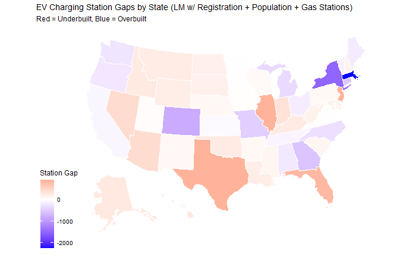

```r
plot_usmap(data = ev_gas_predicted, values = "station_gap", color = "white") +
  scale_fill_gradient2(
    low = "blue", mid = "white", high = "red",
    midpoint = 0, name = "Station Gap"
  ) +
  labs(
    title = "EV Charging Station Gaps by State (LM w/ Registration + Population + Gas Stations)",
    subtitle = "Red = Underbuilt, Blue = Overbuilt"
  )

ggsave("outputs/ev_charging_station_gaps_by_state_2.png", bg = "skyblue")
```

similar results, so let’s try a random forest regressor

```r
library(randomForest)

model_rfr_gas = randomForest(total_stations ~ registration_count + population + gas_stations, data = ev_gas_stats)
summary(model_rfr_gas)
```

```
                Length Class  Mode
call              3    -none- call
type              1    -none- character
predicted        50    -none- numeric
mse             500    -none- numeric
rsq             500    -none- numeric
oob.times        50    -none- numeric
importance        3    -none- numeric
importanceSD      0    -none- NULL
localImportance   0    -none- NULL
proximity         0    -none- NULL
ntree             1    -none- numeric
mtry              1    -none- numeric
forest           11    -none- list
coefs             0    -none- NULL
y                50    -none- numeric
test              0    -none- NULL
inbag             0    -none- NULL
terms             3    terms  call
```

```r
ev_gas_predicted_rfr <- ev_gas_stats |>
  mutate(expected_stations = round(predict(model_rfr_gas), 0),
         station_gap = expected_stations - total_stations) |>
  arrange(desc(station_gap))

ev_gas_predicted_rfr
```

| X | state | total_stations | registration_count | population | evs_per_station | people_per_station | pop_with_ev | gas_stations | expected_stations | station_gap |
| --- | --- | --- | --- | --- | --- | --- | --- | --- | --- | --- |
| 18 | TX | 3834 | 230125 | 29149458 | 60.02 | 7602.88 | 0.0079 | 13715 | 7181 | 3347 |
| 16 | GA | 2173 | 92368 | 10713755 | 42.51 | 4930.40 | 0.0086 | 8471 | 3250 | 1077 |
| 7 | NJ | 1586 | 134753 | 9289014 | 84.96 | 5856.88 | 0.0145 | 3333 | 2560 | 974 |
| 8 | AZ | 1454 | 89798 | 7158110 | 61.76 | 4923.05 | 0.0125 | 2027 | 2322 | 868 |
| 43 | AL | 506 | 13047 | 5025369 | 25.78 | 9931.56 | 0.0026 | 6300 | 1262 | 756 |
| 37 | IN | 659 | 26101 | 6786587 | 39.61 | 10298.31 | 0.0038 | 3069 | 1328 | 669 |
| 30 | TN | 1050 | 33221 | 6912347 | 31.64 | 6583.19 | 0.0048 | 4400 | 1714 | 664 |
| 11 | FL | 3801 | 254878 | 21538192 | 67.06 | 5666.45 | 0.0118 | 9037 | 4333 | 532 |
| 12 | MD | 1412 | 72139 | 6181629 | 51.09 | 4377.92 | 0.0117 | 1990 | 1925 | 513 |
| 19 | IL | 1546 | 99573 | 12821814 | 64.41 | 8293.54 | 0.0078 | 3875 | 2027 | 481 |

[output cut: 40 more lines]

random forest considers CA to be vastly overbuilt (which is not true in actuality, but may be compared to other states)

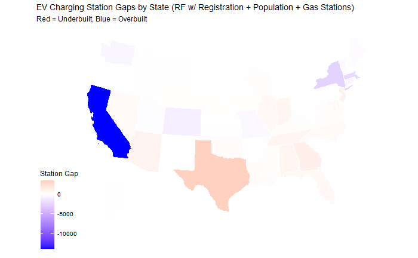

```r
plot_usmap(data = ev_gas_predicted_rfr, values = "station_gap", color = "white") +
  scale_fill_gradient2(
    low = "blue", mid = "white", high = "red",
    midpoint = 0, name = "Station Gap"
  ) +
  labs(
    title = "EV Charging Station Gaps by State (RF w/ Registration + Population + Gas Stations)",
    subtitle = "Red = Underbuilt, Blue = Overbuilt"
  )

ggsave("outputs/ev_charging_station_gaps_by_state_3.png", bg = "skyblue")
```

let’s try gradient boosting before I add any additional features to the analysis

|  | var | rel.inf |
| --- | --- | --- |
| registration_count | registration_count | 39.62881 |
| gas_stations | gas_stations | 32.37519 |
| population | population | 27.99600 |

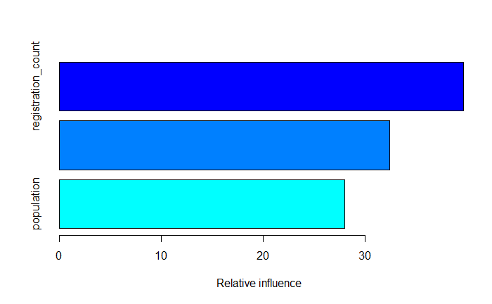

```r
library(gbm)

model_gbm_gas = gbm(total_stations ~ registration_count + population + gas_stations, data = ev_gas_stats,
                    distribution = "gaussian", n.trees = 100)
summary(model_gbm_gas)
```

```r
ev_gas_predicted_gbm <- ev_gas_stats |>
  mutate(expected_stations = round(predict(model_gbm_gas), 0),
         station_gap = expected_stations - total_stations) |>
  arrange(desc(station_gap))

ev_gas_predicted_gbm
```

| X | state | total_stations | registration_count | population | evs_per_station | people_per_station | pop_with_ev | gas_stations | expected_stations | station_gap |
| --- | --- | --- | --- | --- | --- | --- | --- | --- | --- | --- |
| 19 | IL | 1546 | 99573 | 12821814 | 64.41 | 8293.54 | 0.0078 | 3875 | 3149 | 1603 |
| 21 | NC | 1863 | 70164 | 10441499 | 37.66 | 5604.67 | 0.0067 | 6270 | 3385 | 1522 |
| 14 | VA | 1781 | 84936 | 8631388 | 47.69 | 4846.37 | 0.0098 | 3939 | 3260 | 1479 |
| 16 | GA | 2173 | 92368 | 10713755 | 42.51 | 4930.40 | 0.0086 | 8471 | 3578 | 1405 |
| 26 | PA | 1967 | 70154 | 13002909 | 35.67 | 6610.53 | 0.0054 | 4685 | 3263 | 1296 |
| 7 | NJ | 1586 | 134753 | 9289014 | 84.96 | 5856.88 | 0.0145 | 3333 | 2605 | 1019 |
| 2 | WA | 2643 | 152101 | 7707586 | 57.55 | 2916.23 | 0.0197 | 4018 | 3578 | 935 |
| 8 | AZ | 1454 | 89798 | 7158110 | 61.76 | 4923.05 | 0.0125 | 2027 | 2269 | 815 |
| 43 | AL | 506 | 13047 | 5025369 | 25.78 | 9931.56 | 0.0026 | 6300 | 1168 | 662 |
| 12 | MD | 1412 | 72139 | 6181629 | 51.09 | 4377.92 | 0.0117 | 1990 | 2058 | 646 |

[output cut: 40 more lines]

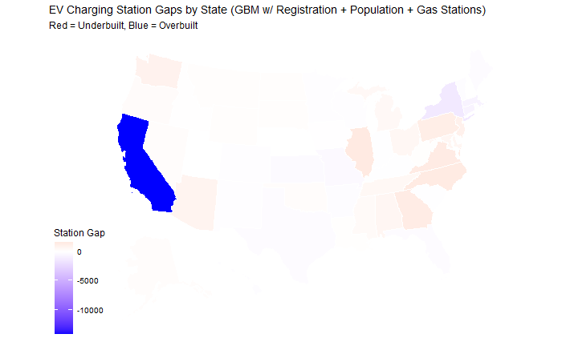

```r
plot_usmap(data = ev_gas_predicted_gbm, values = "station_gap", color = "white") +
  scale_fill_gradient2(
    low = "blue", mid = "white", high = "red",
    midpoint = 0, name = "Station Gap"
  ) +
  labs(
    title = "EV Charging Station Gaps by State (GBM w/ Registration + Population + Gas Stations)",
    subtitle = "Red = Underbuilt, Blue = Overbuilt"
  )

ggsave("outputs/ev_charging_station_gaps_by_state_4.png", bg = "skyblue")
```

let’s clean up some of the column names before this gets even more confusing

```r
ev_gas <- ev_gas_stats |>
  rename(ev_stations = total_stations,
         ev_registrations = registration_count)

ev_gas
```

| X | state | ev_stations | ev_registrations | population | evs_per_station | people_per_station | pop_with_ev | gas_stations |
| --- | --- | --- | --- | --- | --- | --- | --- | --- |
| 1 | CA | 17797 | 1256646 | 39555674 | 70.61 | 2222.60 | 0.0318 | 10100 |
| 2 | WA | 2643 | 152101 | 7707586 | 57.55 | 2916.23 | 0.0197 | 4018 |
| 3 | HI | 383 | 25565 | 1455252 | 66.75 | 3799.61 | 0.0176 | 421 |
| 4 | CO | 2495 | 90083 | 5775324 | 36.11 | 2314.76 | 0.0156 | 2188 |
| 5 | NV | 610 | 47361 | 3105595 | 77.64 | 5091.14 | 0.0153 | 1036 |
| 6 | OR | 1464 | 64361 | 4237224 | 43.96 | 2894.28 | 0.0152 | 2010 |
| 7 | NJ | 1586 | 134753 | 9289014 | 84.96 | 5856.88 | 0.0145 | 3333 |
| 8 | AZ | 1454 | 89798 | 7158110 | 61.76 | 4923.05 | 0.0125 | 2027 |
| 9 | UT | 923 | 39998 | 3271608 | 43.33 | 3544.54 | 0.0122 | 1087 |
| 10 | VT | 486 | 7816 | 643082 | 16.08 | 1323.21 | 0.0122 | 658 |

[output cut: 40 more lines]

import state geographic data and convert to state abbreviations State Area Data: https://www.census.gov/geographies/reference-files/2010/geo/state-area.html

```r
state_areas <- read.csv("data/state_areas.csv")
state_areas$state <- state.abb[match(state_areas$state, state.name)]
state_areas
```

| state | sq_mi |
| --- | --- |
| AL | 52420 |
| AK | 665384 |
| AZ | 113990 |
| AR | 53179 |
| CA | 163695 |
| CO | 104094 |
| CT | 5543 |
| DE | 2489 |
| FL | 65758 |
| GA | 59425 |

[output cut: 40 more lines]

join with dataset

```r
ev_gas_area <- ev_gas |>
  left_join(state_areas) |>
  arrange(desc(sq_mi))

ev_gas_area
```

| X | state | ev_stations | ev_registrations | population | evs_per_station | people_per_station | pop_with_ev | gas_stations | sq_mi |
| --- | --- | --- | --- | --- | --- | --- | --- | --- | --- |
| 39 | AK | 63 | 2697 | 733395 | 42.81 | 11641.19 | 0.0037 | 361 | 665384 |
| 18 | TX | 3834 | 230125 | 29149458 | 60.02 | 7602.88 | 0.0079 | 13715 | 268596 |
| 1 | CA | 17797 | 1256646 | 39555674 | 70.61 | 2222.60 | 0.0318 | 10100 | 163695 |
| 33 | MT | 142 | 4608 | 1084216 | 32.45 | 7635.32 | 0.0043 | 558 | 147040 |
| 29 | NM | 401 | 10276 | 2117555 | 25.63 | 5280.69 | 0.0049 | 1188 | 121590 |
| 8 | AZ | 1454 | 89798 | 7158110 | 61.76 | 4923.05 | 0.0125 | 2027 | 113990 |
| 5 | NV | 610 | 47361 | 3105595 | 77.64 | 5091.14 | 0.0153 | 1036 | 110572 |
| 4 | CO | 2495 | 90083 | 5775324 | 36.11 | 2314.76 | 0.0156 | 2188 | 104094 |
| 6 | OR | 1464 | 64361 | 4237224 | 43.96 | 2894.28 | 0.0152 | 2010 | 98379 |
| 45 | WY | 102 | 1139 | 576844 | 11.17 | 5655.33 | 0.0020 | 299 | 97813 |

[output cut: 40 more lines]

create new linear model factoring in sq_miles (land area for each state) note: re-running other models with same dataset for analysis

```r
model_lm <- lm(ev_stations ~ ev_registrations + population, data = ev_gas_area)
model_lm_gas <- lm(ev_stations ~ ev_registrations + population + gas_stations, data = ev_gas_area)
model_lm_area <- lm(ev_stations ~ ev_registrations + population + sq_mi, data = ev_gas_area)
model_lm_gas_area<- lm(ev_stations ~ ev_registrations + population + gas_stations + sq_mi, data = ev_gas_area)

summary(model_lm)
```

```
Call:
lm(formula = ev_stations ~ ev_registrations + population, data = ev_gas_area)

Residuals:
    Min      1Q  Median      3Q     Max
-1031.5  -204.5  -102.7   123.2  2277.3

Coefficients:
                  Estimate Std. Error t value Pr(>|t|)
(Intercept)      1.881e+02  1.134e+02   1.659 0.103750
ev_registrations 1.184e-02  7.525e-04  15.734  < 2e-16 ***
population       6.699e-05  1.821e-05   3.679 0.000602 ***
---
Signif. codes:  0 ‘***’ 0.001 ‘**’ 0.01 ‘*’ 0.05 ‘.’ 0.1 ‘ ’ 1

Residual standard error: 547.3 on 47 degrees of freedom
Multiple R-squared:  0.9578,    Adjusted R-squared:  0.956
F-statistic: 533.6 on 2 and 47 DF,  p-value: < 2.2e-16
```

```r
summary(model_lm_gas)
```

```
Call:
lm(formula = ev_stations ~ ev_registrations + population + gas_stations,
    data = ev_gas_area)

Residuals:
    Min      1Q  Median      3Q     Max
-890.79 -218.42  -81.49  163.52 2244.45

Coefficients:
                   Estimate Std. Error t value Pr(>|t|)
(Intercept)       2.490e+02  1.186e+02   2.099  0.04132 *
ev_registrations  1.107e-02  8.958e-04  12.358 3.21e-16 ***
population        1.178e-04  3.766e-05   3.127  0.00306 **
gas_stations     -1.097e-01  7.152e-02  -1.534  0.13184
---
Signif. codes:  0 ‘***’ 0.001 ‘**’ 0.01 ‘*’ 0.05 ‘.’ 0.1 ‘ ’ 1

Residual standard error: 539.6 on 46 degrees of freedom
Multiple R-squared:  0.9599,    Adjusted R-squared:  0.9573
F-statistic: 366.8 on 3 and 46 DF,  p-value: < 2.2e-16
```

```r
summary(model_lm_area)
```

```
Call:
lm(formula = ev_stations ~ ev_registrations + population + sq_mi,
    data = ev_gas_area)

Residuals:
    Min      1Q  Median      3Q     Max
-886.17 -197.12  -97.58  118.79 2217.06

Coefficients:
                   Estimate Std. Error t value Pr(>|t|)
(Intercept)       2.505e+02  1.257e+02   1.992 0.052349 .
ev_registrations  1.189e-02  7.516e-04  15.821  < 2e-16 ***
population        6.753e-05  1.816e-05   3.718 0.000544 ***
sq_mi            -9.161e-04  8.093e-04  -1.132 0.263512
---
Signif. codes:  0 ‘***’ 0.001 ‘**’ 0.01 ‘*’ 0.05 ‘.’ 0.1 ‘ ’ 1

Residual standard error: 545.7 on 46 degrees of freedom
Multiple R-squared:  0.959, Adjusted R-squared:  0.9563
F-statistic: 358.3 on 3 and 46 DF,  p-value: < 2.2e-16
```

```r
summary(model_lm_gas_area)
```

```
Call:
lm(formula = ev_stations ~ ev_registrations + population + gas_stations +
    sq_mi, data = ev_gas_area)

Residuals:
    Min      1Q  Median      3Q     Max
-950.02 -213.96  -87.13  151.17 2183.66

Coefficients:
                   Estimate Std. Error t value Pr(>|t|)
(Intercept)       3.120e+02  1.301e+02   2.398  0.02072 *
ev_registrations  1.112e-02  8.935e-04  12.445  3.6e-16 ***
population        1.185e-04  3.753e-05   3.158  0.00284 **
gas_stations     -1.101e-01  7.126e-02  -1.545  0.12923
sq_mi            -9.222e-04  7.973e-04  -1.157  0.25355
---
Signif. codes:  0 ‘***’ 0.001 ‘**’ 0.01 ‘*’ 0.05 ‘.’ 0.1 ‘ ’ 1

Residual standard error: 537.6 on 45 degrees of freedom
Multiple R-squared:  0.961, Adjusted R-squared:  0.9576
F-statistic: 277.4 on 4 and 45 DF,  p-value: < 2.2e-16
```

visualize based on combination

```r
ev_gas_area_predicted_lm<- ev_gas_area |>
  mutate(expected_stations = round(predict(model_lm_gas_area), 0),
         station_gap = expected_stations - ev_stations) |>
  arrange(desc(station_gap))

ev_gas_area_predicted_lm
```

| X | state | ev_stations | ev_registrations | population | evs_per_station | people_per_station | pop_with_ev | gas_stations | sq_mi | expected_stations | station_gap |
| --- | --- | --- | --- | --- | --- | --- | --- | --- | --- | --- | --- |
| 7 | NJ | 1586 | 134753 | 9289014 | 84.96 | 5856.88 | 0.0145 | 3333 | 8723 | 2536 | 950 |
| 19 | IL | 1546 | 99573 | 12821814 | 64.41 | 8293.54 | 0.0078 | 3875 | 57914 | 2458 | 912 |
| 11 | FL | 3801 | 254878 | 21538192 | 67.06 | 5666.45 | 0.0118 | 9037 | 65758 | 4643 | 842 |
| 18 | TX | 3834 | 230125 | 29149458 | 60.02 | 7602.88 | 0.0079 | 13715 | 268596 | 4567 | 733 |
| 5 | NV | 610 | 47361 | 3105595 | 77.64 | 5091.14 | 0.0153 | 1036 | 110572 | 991 | 381 |
| 8 | AZ | 1454 | 89798 | 7158110 | 61.76 | 4923.05 | 0.0125 | 2027 | 113990 | 1830 | 376 |
| 37 | IN | 659 | 26101 | 6786587 | 39.61 | 10298.31 | 0.0038 | 3069 | 36420 | 1035 | 376 |
| 3 | HI | 383 | 25565 | 1455252 | 66.75 | 3799.61 | 0.0176 | 421 | 10932 | 712 | 329 |
| 42 | KY | 354 | 11617 | 4506302 | 32.82 | 12729.67 | 0.0026 | 2922 | 40408 | 616 | 262 |
| 24 | OK | 380 | 22843 | 3959405 | 60.11 | 10419.49 | 0.0058 | 3200 | 69899 | 618 | 238 |

[output cut: 40 more lines]

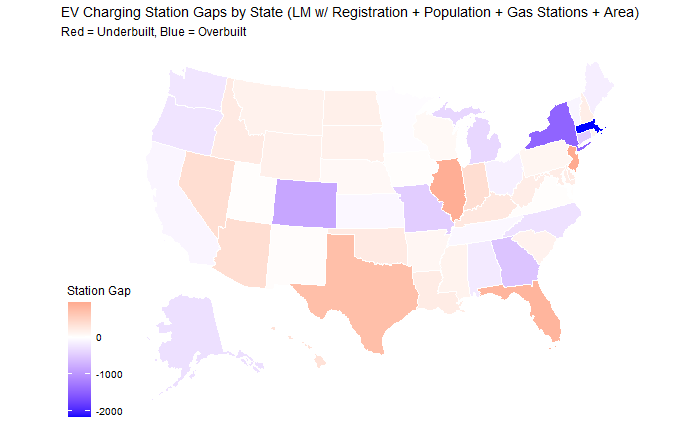

```r
plot_usmap(data = ev_gas_area_predicted_lm, values = "station_gap", color = "white") +
  scale_fill_gradient2(
    low = "blue", mid = "white", high = "red",
    midpoint = 0, name = "Station Gap"
  ) +
  labs(
    title = "EV Charging Station Gaps by State (LM w/ Registration + Population + Gas Stations + Area)",
    subtitle = "Red = Underbuilt, Blue = Overbuilt"
  )

ggsave("outputs/ev_charging_station_gaps_by_state_5.png", bg = "skyblue")
```

I like the looks of this map. Including area seemed to eliminate some of the extreme predictions. This now seems like a much more nuanced look at which states are under- or overbuilt. But do the statistics agree?

```r
anova(model_lm, model_lm_gas)
```

```
Analysis of Variance Table

Model 1: ev_stations ~ ev_registrations + population
Model 2: ev_stations ~ ev_registrations + population + gas_stations
  Res.Df      RSS Df Sum of Sq      F Pr(>F)
1     47 14079856
2     46 13394522  1    685333 2.3536 0.1318
```

```r
anova(model_lm, model_lm_area)
```

```
Analysis of Variance Table

Model 1: ev_stations ~ ev_registrations + population
Model 2: ev_stations ~ ev_registrations + population + sq_mi
  Res.Df      RSS Df Sum of Sq      F Pr(>F)
1     47 14079856
2     46 13698280  1    381576 1.2814 0.2635
```

```r
anova(model_lm, model_lm_gas_area)
```

```
Analysis of Variance Table

Model 1: ev_stations ~ ev_registrations + population
Model 2: ev_stations ~ ev_registrations + population + gas_stations +
    sq_mi
  Res.Df      RSS Df Sum of Sq      F Pr(>F)
1     47 14079856
2     45 13007847  2   1072008 1.8543 0.1683
```

adding gas, gas+area does not result in statistical significance against the original model however, adding area does work to eliminate extremes, so may not be completely useless

let’s try a random forest model just to see if it may do a better job

```r
model_rfr <- randomForest(ev_stations ~ ev_registrations + population, data = ev_gas_area)
model_rfr_gas <- randomForest(ev_stations ~ ev_registrations + population + gas_stations, data = ev_gas_area)
model_rfr_area <- randomForest(ev_stations ~ ev_registrations + population + sq_mi, data = ev_gas_area)
model_rfr_gas_area<- randomForest(ev_stations ~ ev_registrations + population + gas_stations + sq_mi, data = ev_gas_area)

importance(model_rfr)
```

```
                 IncNodePurity
ev_registrations     166211413
population           159638760
```

```r
importance(model_rfr_gas)
```

```
                 IncNodePurity
ev_registrations      98320944
population           117138490
gas_stations          88370062
```

```r
importance(model_rfr_area)
```

```
                 IncNodePurity
ev_registrations     113508629
population           117642406
sq_mi                 59906338
```

```r
importance(model_rfr_gas_area)
```

```
                 IncNodePurity
ev_registrations      83600267
population            94042790
gas_stations          62895225
sq_mi                 44389758
```

```
An rfPermute model

               Type of random forest: regression
                     Number of trees: 500
No. of variables tried at each split: 1
       No. of permutation replicates: 100
                          Start time: 2025-08-11 21:25:11
                            End time: 2025-08-11 21:25:12
                            Run time: 1.12 secs

          Mean of squared residuals: 4226438
                    % Var explained: 36.7
```

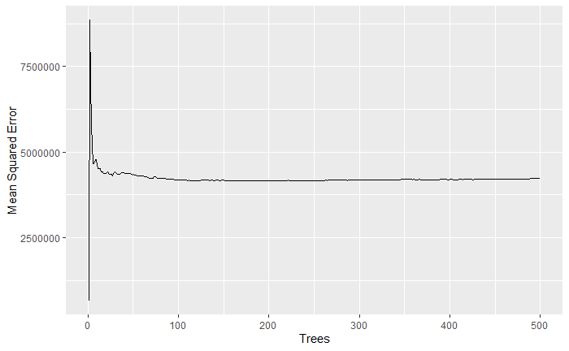

```r
library(rfPermute)

model_rfr_perm <- rfPermute(ev_stations ~ ev_registrations + population, data = ev_gas_area)
model_rfr_gas_perm <- rfPermute(ev_stations ~ ev_registrations + population + gas_stations, data = ev_gas_area)
model_rfr_area_perm <- rfPermute(ev_stations ~ ev_registrations + population + sq_mi, data = ev_gas_area)
model_rfr_gas_area_perm <- rfPermute(ev_stations ~ ev_registrations + population + gas_stations + sq_mi, data = ev_gas_area)

summary(model_rfr_perm)
```

```
An rfPermute model

               Type of random forest: regression
                     Number of trees: 500
No. of variables tried at each split: 1
       No. of permutation replicates: 100
                          Start time: 2025-08-11 21:25:12
                            End time: 2025-08-11 21:25:13
                            Run time: 1.16 secs

          Mean of squared residuals: 4441303
                    % Var explained: 33.5
```

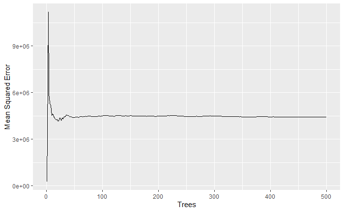

```r
summary(model_rfr_gas_perm)
```

```
An rfPermute model

               Type of random forest: regression
                     Number of trees: 500
No. of variables tried at each split: 1
       No. of permutation replicates: 100
                          Start time: 2025-08-11 21:25:13
                            End time: 2025-08-11 21:25:15
                            Run time: 1.14 secs

          Mean of squared residuals: 4979732
                    % Var explained: 25.4
```

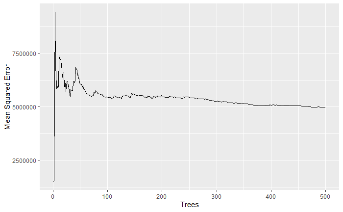

```r
summary(model_rfr_area_perm)
```

```
An rfPermute model

               Type of random forest: regression
                     Number of trees: 500
No. of variables tried at each split: 1
       No. of permutation replicates: 100
                          Start time: 2025-08-11 21:25:15
                            End time: 2025-08-11 21:25:16
                            Run time: 1.18 secs

          Mean of squared residuals: 4908610
                    % Var explained: 26.5
```

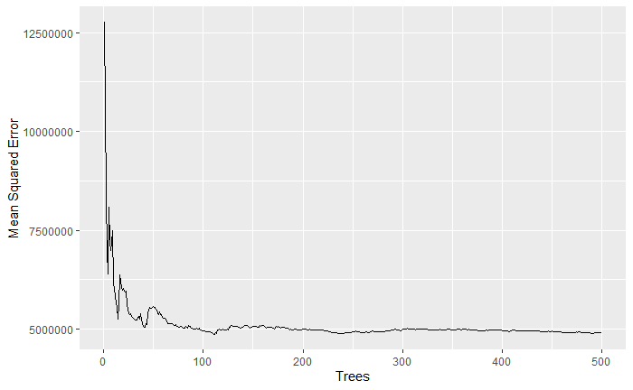

```r
summary(model_rfr_gas_area_perm)
```

rfr performed poorly, so I will stick with the linear model why - too low percentage of explained variance